# Лабораторная работа №7

Дискретно-событийное моделирование

Софич Андрей Геннадьевич

safich05@mail.ru

Российский университет дружбы народов

2026-10-05

## Докладчик

- Софич Андрей Геннадьевич

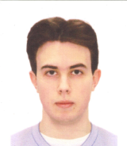

# Актуальность

## Актуальность

Изучить основные модели теории массового обслуживания

# Цель

## Цели и задачи

Применить модели на задачах, выполнить несколько различных симуляций.

# Выполнение лабораторной работы

## Выполнение лабораторной работы

Создаем рабочий каталог и инициализируем проект в julia .

[figure not shown]

Инициализация проекта

Создаем файл, где прописываем пакеты, необходимые для выполнения работы и запускаем его .

[figure not shown]

Подключение необходимых пакетов

Создаем файл в папке scripts, реализуем в нем модель M/M/c, которая будет симулировать и анализровать входящие потоки, обслуживания их интенсивности и занятость приборов(каналов) на 10 клиентах(customers)и 2 серверах(каналах)

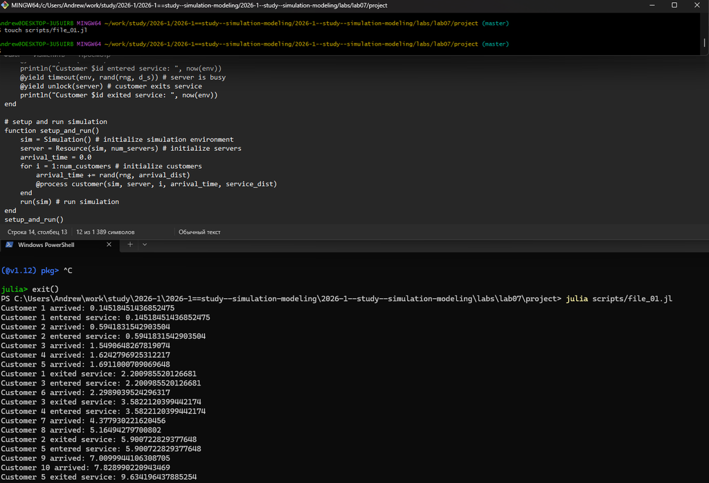

Создание файла для реализации M/M/c

Преобразовываем код в произвольные стили и открываем один из них, чтобы убедиться в правильности компиляции

[figure not shown]

Код в стиле jupyter notebook

Создаем файл, в котором добавляем графики: диаграмма обслуживания, кол-во клиентов в системе, время ожидания по клиентам

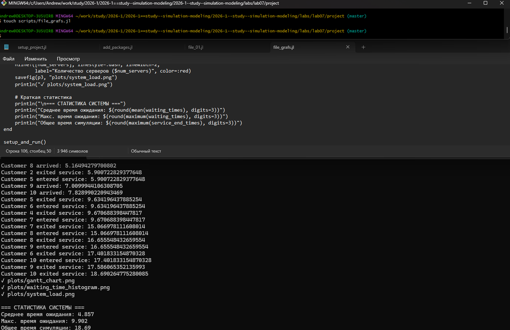

Файл с графиками

Первый график:диаграмма обслуживания - мы видим как система принимает клиентов и насколько долго обрабатывается каждый клиент

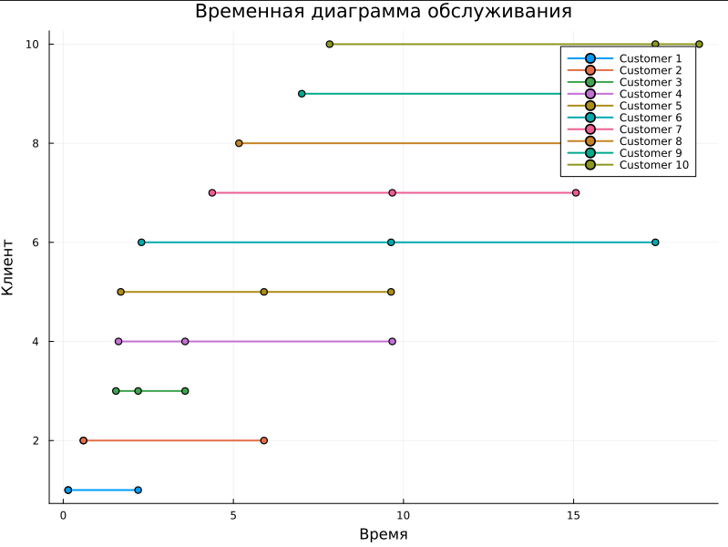

Диграмма обслуживания

Второй график: кол-во клиентов в системе - мы видим как со временем меняется количество клиентов в системе, кто-то ждет, кто то уже обрабатывается сервером

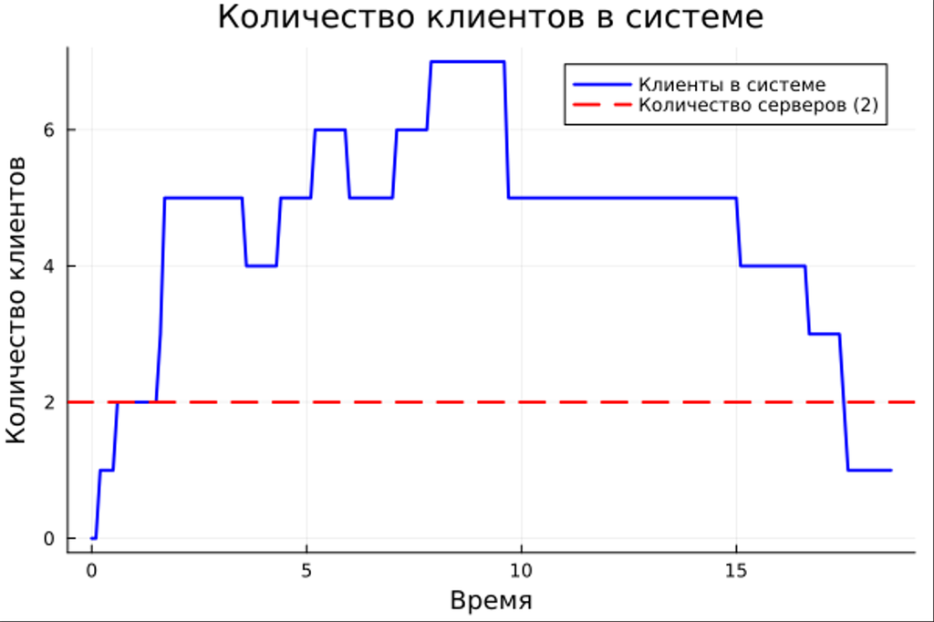

Количество клиентов в системе

Третий график: время ожидания по клиентам - мы видим, как скапливаются клиенты, образуются очереди и сколько customers приходится ждать пока освободится сервер

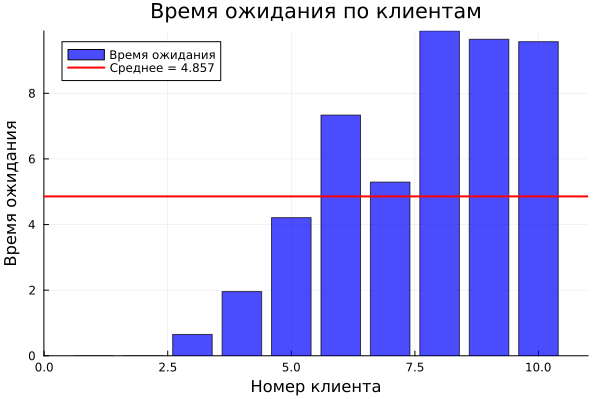

Время ожидания по клиентам

Преобразовываем код в произвольные стили и открываем один из них, чтобы убедиться в правильности компиляции

[figure not shown]

Код в стиле jupyter notebook

Переходим в модель Росса, для начала реализуем обычные симуляции с параметрами (рабочие машины, запасные, время починки, время поломки и тд.)

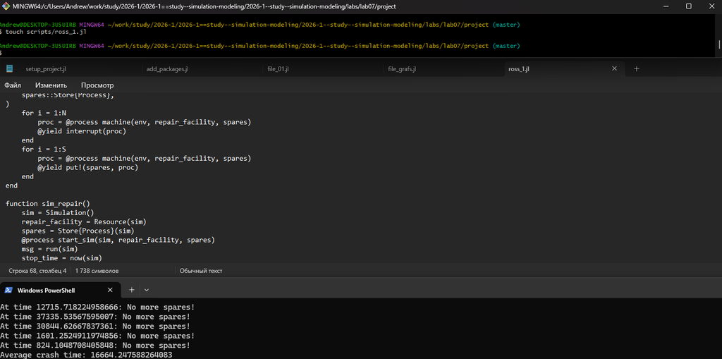

Первый прогон модели Росса

Преобразовываем код в произвольные стили и открываем один из них, чтобы убедиться в правильности компиляции

[figure not shown]

Код в стиле jupyter notebook

Преобразовываем код, добавляем ремонтников, я решил взять 5, как мы видим, время работы системы сильно увеличилось

[figure not shown]

Преобразовываем код в произвольные стили и открываем один из них, чтобы убедиться в правильности компиляции

[figure not shown]

Код в стиле jupyter notebook

Теперь проводим симуляцию с разным количество работающих машин(N=30), оставляем резерв таким же, как мы видим, система довольно быстро вышла из строя, что не удивительно

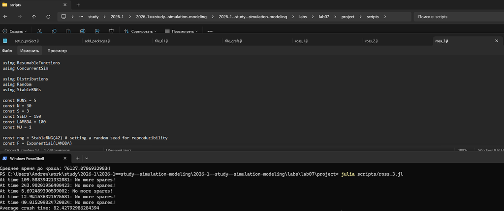

Преобразовываем код в произвольные стили и открываем один из них, чтобы убедиться в правильности компиляции

[figure not shown]

Код в стиле jupyter notebook

[figure not shown]

Загрузка ремонтника

Преобразовываем код в произвольные стили и открываем один из них, чтобы убедиться в правильности компиляции

[figure not shown]

Код в стиле jupyter notebook

Создаем график изменения числа исправных машин во времени

[figure not shown]

Добавление графика

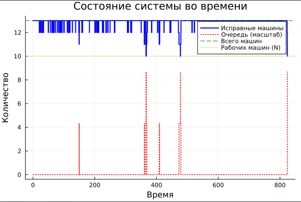

График

Преобразовываем код в произвольные стили и открываем один из них, чтобы убедиться в правильности компиляции

[figure not shown]

Код в стиле jupyter notebook

# Выводы

## Выводы

В данной работе мы изучили и применили дискретно-событийное моделирование.